# Introduction to R

Exam Summer Term 2018

Student Name, Student ID, StudentName@uni-muenster.de

- Answer **7** out of **10** of the following exercises in either German or English.
- Hand in your solutions before Friday, 13 April 2018 at 10 am.
- It is advised to regularly check the learnweb and your emails in case of urgent updates.
- Please sent your solutions files to Willi Mutschler. We will confirm the receipt of your work also by email.
- The solution files should contain your executable and commented script file or preferably a R Notebook.
- You may use *any* available R package you find fit to solve the exercise.
- Please label your axes and title in your plots.
- **All students must work on their own.**

# 1 Linear Equation

Solve the linear equation $A\cdot x = b$ with
$$A = \begin{pmatrix} 1 & 1 & 1 & 3\\ 2 & 5 & 8 & 6\\ 4 & 3 & 7 & 9\\ 3 & 6 & 5 & 1 \end{pmatrix} \text{ and }
b = \begin{pmatrix} 1 \\ 4 \\ 3 \\ 5 \end{pmatrix}$$

*Solution:*

`r`r A = matrix(c(1,2,4,3,1,5,3,6,1,8,7,5,3,6,9,1),4,4) b = matrix(c(1,4,3,5),4,1) x=solve(A,b) print(x)

```
            [,1]
[1,]  0.20512821
[2,]  0.76923077
[3,] -0.05128205
[4,]  0.02564103
```

and compute the inverse as well as Eigenvalues of $A$.

*Solution:*

`r`r solve(A)

```
           [,1]        [,2]        [,3]        [,4]
[1,] -0.3589744 -0.43589744  0.38461538  0.23076923
[2,]  0.6538462  0.11538462 -0.30769231  0.11538462
[3,] -0.6602564  0.10897436  0.15384615 -0.05769231
[4,]  0.4551282  0.07051282 -0.07692308 -0.09615385
```

`r`r eigen(A)$values

```
[1] 17.543241+0.000000i -3.624256+0.000000i  0.040507+1.565859i  0.040507-1.565859i
```

# 2 Functions

1. Write a function `psum(n,a)` that computes
   $$s_{n,a} := \sum_{k=0}^n \frac{k^a}{k^a+1}$$
   for any natural number $n \in \{1,2,...\}$ and any $a > 0$.

*Solution:*

[output not shown]

2. Write a function `mymatrix(n)` that returns a $n \times n$ matrix such that: the first and last row as well as the first and last column contain only ones, whereas the remaining values are zero, e.g.
   $$\begin{pmatrix} 1 & 1 & 1 & 1\\ 1&0&0&1\\1&0&0&1\\1 & 1 & 1 & 1
   \end{pmatrix}$$

*Solution:*

`r`r mymatrix = function(n){ matrix(c(rep(1,n),rep(c(1,rep(0,n-2),1),n-2),rep(1,n)),n,n) } mymatrix(4)

```
     [,1] [,2] [,3] [,4]
[1,]    1    1    1    1
[2,]    1    0    0    1
[3,]    1    0    0    1
[4,]    1    1    1    1
```

# 3 Passenger numbers

The file **apass.csv** contains monthly data on passenger numbers of US airlines from January 1949 to December 1959.

1. Read the data into a data frame.

*Solution:*

2. Create a vector that contains the corresponding dates. Add this vector to your data frame.

*Solution:*

3. Plot the passenger numbers against the date vector.

*Solution:*

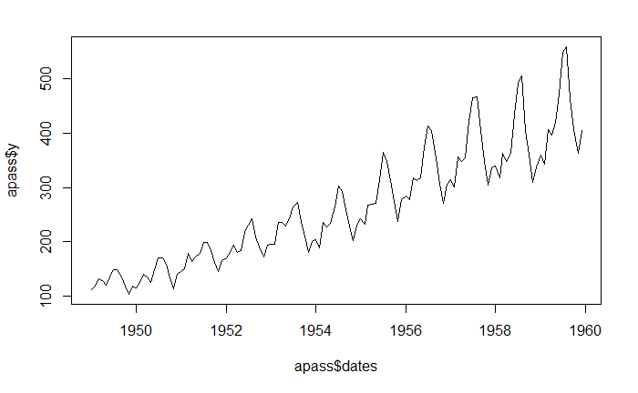

4. Calculate the mean passenger numbers for each month. Plot the means as a bar chart.

*Solution:*

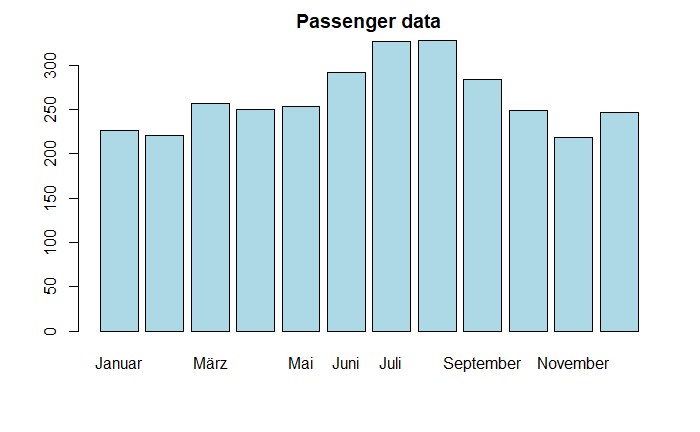

# 4 Porsche

The file **Porsche911.csv** contains data on Porsche 911 cars, `name` is an id for the owner, `loc` is the location, `age` is the age of the car, `TKM` is the mileage in thousands kilometers and `price` the current price listed on an internet plattform for used cars in thousand Euros.

1. Read in the data into a data frame and compute key descriptive statistics (mean, standard deviation, smallest and largest values, quartiles, covariance and correlation) for the variables `age`, `TKM` and `price`.

*Solution:*

`r`r cov(Porsche911)

```
            age       TKM     price
age    140.3583  194.4894 -251.5397
TKM    194.4894  686.3065 -451.6083
price -251.5397 -451.6083  587.8436
```

`r`r cor(Porsche911)

```
             age        TKM      price
age    1.0000000  0.6266396 -0.8757026
TKM    0.6266396  1.0000000 -0.7110039
price -0.8757026 -0.7110039  1.0000000
```

2. Plot boxplots for `age`, `TKM` and `price`.

*Solution:*

`r`r boxplot(Porsche911)

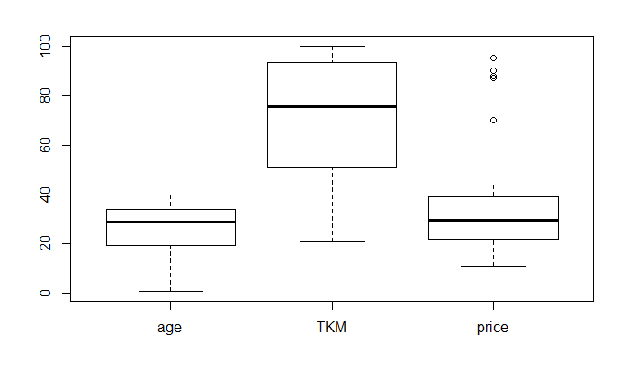

3. Generate the empirical cumulative distribution function as well as histograms for each of the variables `age`, `TKM` and `price`.

*Solution:*

`r`r library(MASS) par(mfrow=c(1,3)) truehist(Porsche911$age) truehist(Porsche911$TKM) r truehist(Porsche911$price)

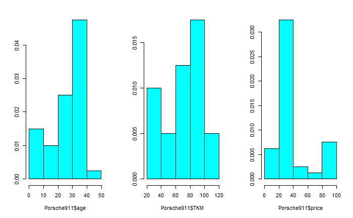

[figure not shown]

# 5 Law of large numbers

Let $X_1, X_2,...$ be a sequence $X_1,X_2,...$ from an $AR(1)$ process:
$$\left( X_{i}-\mu \right) =\rho \left( X_{i-1}-\mu \right) +\varepsilon _{i}$$
where $\varepsilon _{i}$ is uniformly distributed on the interval $[-1,1]$ and $|\rho |<1$. Define the sequence of random variables
$$\bar{X}_{n}=\frac{1}{n}\sum_{i=1}^{n}X_{i}.$$
The weak law of large numbers states that the sample average $\bar{X}_{n}$ converges in probability towards the expected value $\mu$ when $n$ tends to infinity.

Show by simulation that the law of large numbers holds despite the intertemporal dependence in $X$. In particular, show the convergence by means of an appropriate plot. Hint: You may set the parameters to e.g. $\rho=0.5$ and $\mu=2$ (or any other value you find fit.)

*Solution:*

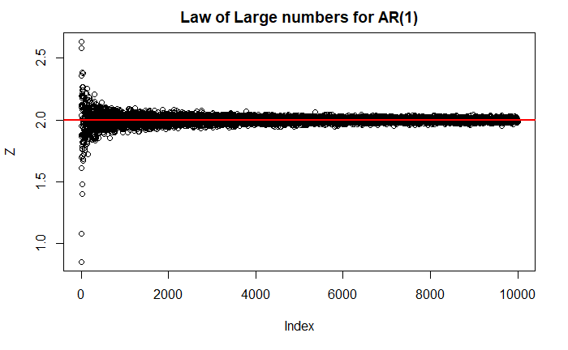

# 6 Limits of maxima

Let $X_{1}, X_{2},...$ be an i.i.d. sequence of random variables uniformly distributed on the interval $[0,1]$. Define the random variables
$$M_{n}=\max_{i=1,\ldots ,n}X_{i}$$
and its normalized version $\overline{M}_{n}=(M_{n}-1)\cdot n$. One can show that the limit distribution of $\overline{M}_{n}$ is the Weibull distribution with density $\exp \left( x\right)$. Write an R program to illustrate that $\overline{M}_{n}$ converges in distribution. To this end, set $n=100$ and $R=1000$ and consider the $R \times n$ matrix with uniformly distributed random variables $X_i$. Show the convergence by means of an appropriate plot.

Note: Try to avoid using loops (use e.g. apply instead). You will not get full points if you use a loop.

*Solution:*

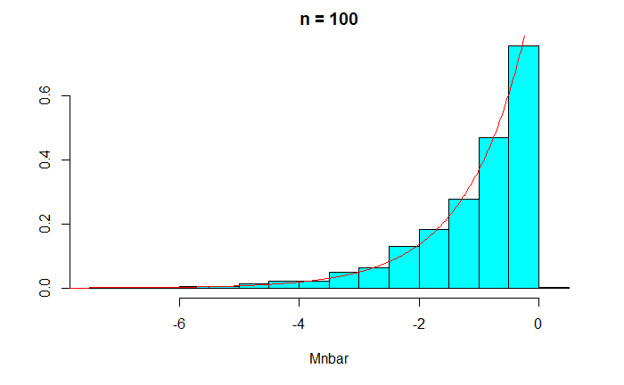

# 7 Student teacher ratio

Load the dataset **caschool.csv** into the object `caschool`. This dataset is discussed in great detail in the textbook of Stock and Watson.

1. Make the following variables accessible:
- test score `testscr`
- student-teacher ratio `str`
- percentage of English language learners `el_pct`
- expenditures per student `expn_stu`

*Solution:*

```r
caschool <- read.csv("../data/caschool.csv")
testscr <- caschool$testscr
str <- caschool$str
el_pct <- caschool$el_pct
expn_stu <- caschool$expn_stu
```

2. Regress `testscr` on a constant and `str`. Assign the residuals of the regression into the variable `r1`. Now regress `testscr` on an intercept, `str`, `el_pct` and `expn_stu`. Put the residuals into the variable `r2`. Compute the sum of squared residuals for both regressions. Display `r1` and `r2` in one plot, where the points of `r2` are marked red.

*Solution:*

```r
simple <- lm(testscr~str)
multiple <- lm(testscr~str + el_pct + expn_stu)
r1 <- residuals(simple)
r2 <- residuals(multiple)
sum(r1^2)
```

```
[1] 144315.5
```

```r
sum(r2^2)
```

```
[1] 85699.69
```

```r
sum(r1^2) > sum(r2^2)
```

```
[1] TRUE
```

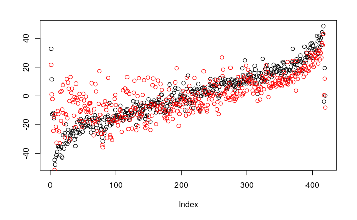

```r
plot(r1,ylab="")
points(r2,col="red")
```

3. Consider the regression of `testscr` on a constant, `str`, `elp_ct` and `expn_stu`. Predict the value of `testscr` for a school district with an average class size (`str`) of 25 students, a percentage of English learners (`el_pct`) of 60% and an average expenditures per student (`expn_stu`) of 4000$.

*Solution:*

```r
predict(multiple, newdata=data.frame(str=25, el_pct=60, expn_stu=4000))
```

```
       1
618.5282
```

4. Reconsider the regression of `testscr` on a constant, `str`, `el_pct` and `expn_stu`. Compute the heteroscedastic robust standard errors.

*Solution:*

`r`r library(lmtest) library(sandwich)

`r`r regr <- lm(testscr~str + el_pct + expn_stu) summary(regr)

```
Call:
lm(formula = testscr ~ str + el_pct + expn_stu)

Residuals:
    Min      1Q  Median      3Q     Max
-51.340 -10.111   0.293  10.318  43.181

Coefficients:
              Estimate Std. Error t value Pr(>|t|)
(Intercept) 649.577960  15.205716  42.719  < 2e-16 ***
str          -0.286400   0.480523  -0.596  0.55149
el_pct       -0.656023   0.039106 -16.776  < 2e-16 ***
expn_stu      0.003868   0.001412   2.739  0.00643 **
---
Signif. codes:  0 ‘***’ 0.001 ‘**’ 0.01 ‘*’ 0.05 ‘.’ 0.1 ‘ ’ 1

Residual standard error: 14.35 on 416 degrees of freedom
Multiple R-squared:  0.4366,    Adjusted R-squared:  0.4325
F-statistic: 107.5 on 3 and 416 DF,  p-value: < 2.2e-16
```

`r`r coeftest(regr, vcov=vcovHC)

```
t test of coefficients:

               Estimate  Std. Error  t value Pr(>|t|)
(Intercept) 649.5779596  15.6686203  41.4573  < 2e-16 ***
str          -0.2863998   0.4875129  -0.5875  0.55721
el_pct       -0.6560228   0.0321143 -20.4278  < 2e-16 ***
expn_stu      0.0038679   0.0016074   2.4063  0.01655 *
---
Signif. codes:  0 ‘***’ 0.001 ‘**’ 0.01 ‘*’ 0.05 ‘.’ 0.1 ‘ ’ 1
```

5. Test the null hypothesis that the coefficients on `str` and `expn_stu` both equal $0$ and the coefficient on `el_pct` equals $-0.7$. Hint: Use the linearHypothesis function of the `car` package.

*Solution:*

```
Linear hypothesis test

Hypothesis:
str = 0
expn_stu = 0
el_pct = - 0.7

Model 1: restricted model
Model 2: testscr ~ str + el_pct + expn_stu

  Res.Df   RSS Df Sum of Sq      F    Pr(>F)
1    419 89117
2    416 85700  3    3416.9 5.5287 0.0009919 ***
---
Signif. codes:  0 ‘***’ 0.001 ‘**’ 0.01 ‘*’ 0.05 ‘.’ 0.1 ‘ ’ 1
```

# 8 Asymptotic normality

Consider the multiple linear regression model $y=X\beta +u$. In R, generate the matrix $X$ by executing the following commands:

`r`r library(MASS) X <- cbind(1,mvrnorm(n=100,c(5,10),matrix(c(1,0.9,0.9,1),2,2)))

Assume that the true coefficient vector is
$$\beta =\left(
\begin{array}{c}
3 \\
2 \\
-1
\end{array}
\right)$$
and the error terms are i.i.d. uniformly distributed on the interval $[-1,1]$. Hence, the assumption of normally distributed error terms is violated.

1. Write an R program that generates $R=10000$ random samples of size $n=100$ each. Generate an empty vector `Z <- rep(NA,R)`. For each sample $i=1,\ldots ,R$, compute the OLS estimate $\hat{\beta}$ of $\beta$ and store the second component of $\hat{\beta}$ in the $i$-th element of the vector `Z`.

*Solution:*

`r`r beta_true <- c(3,2,-1) n <- 100 R <- 10000 Z <- rep(NA,R) for (i in 1:R) { u <- runif(n,-1,1) X <- cbind(1,mvrnorm(n=n,c(5,10),matrix(c(1,0.9,0.9,1),2,2))) y <- X%*%beta_true + u beta_hat <- solve(t(X)%*%X)%*%t(X)%*%y Z[i] <- beta_hat[2] }

2. Plot the histogram of `Z`. Compute the mean $m$ and standard deviation $s$ of `Z` and add the density of $N(m,s)$ to the plot.

*Solution:*

`r`r library(MASS) truehist(Z) m1 <- mean(Z) s1 <- sd(Z) curve(dnorm(x,mean=m1,sd=s1),add=T)

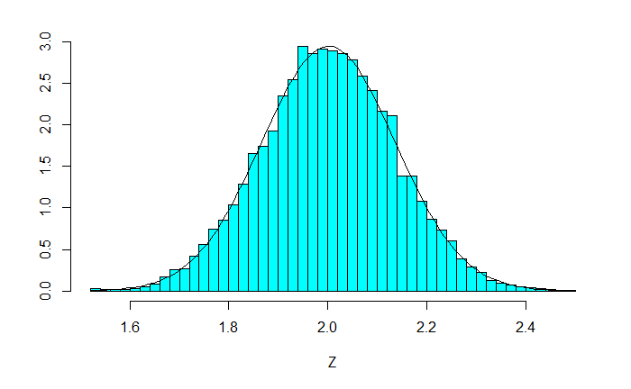

# 9 Stochastic frontier analysis

Consider the Cobb-Douglas production function
$$y=Ax_{1}^{\alpha }x_{2}^{\beta }$$
By definition, the production function returns the maximal output for given inputs, and actual production cannot be larger than $y$. Due to inefficiencies, actual production could be modeled (in logs) as
$$\ln y=\ln A+\alpha \ln x_{1}+\beta \ln x_{2}-u$$
where $u$ is a **non-negative** random variable. Since other disturbances (e.g. measurement errors) can enter the production function, it is more common to add another, **symmetrically distributed**, disturbance term $v$,
$$\ln y=\ln A+\alpha \ln x_{1}+\beta \ln x_{2}-u+v$$
Assume that $u$ is exponentially ($u \sim Exp(\lambda)$) and $v$ normally ($v\sim N(0,\sigma^{2})$) distributed. One can show that if $u$ and $v$ are independent then the density function of $\varepsilon =v-u$ is given by
$$f_{\varepsilon} (\varepsilon) =\lambda \exp\left(\lambda \varepsilon + \frac{1}{2} \lambda^{2} \sigma^{2}\right) \Phi \left( \frac{-\varepsilon}{\sigma} -\lambda \sigma \right)$$
where $\Phi$ is the distribution function (`pnorm`) of $N(0,1)$ and $\exp$ the exponential function (`exp`).

1. Load the dataset **sfa.csv**. This dataset is an abbreviated version of table F7.2 of Greene, 2008. The original data appeared in Zellner and Revankar, *Generalized Production Functions*, Review of Economic Studies, 36 (1969), 241-250.

*Solution:*

|  | State | ValueAdd | Capital | Labor |
| --- | --- | --- | --- | --- |
| 1 | Alabama | 126.148 | 3.804 | 31.551 |
| 2 | California | 3201.486 | 185.446 | 452.844 |
| 3 | Connecticut | 690.670 | 39.712 | 124.074 |
| 4 | Florida | 56.296 | 6.547 | 19.181 |
| 5 | Georgia | 304.531 | 11.530 | 45.534 |
| 6 | Illinois | 723.028 | 58.987 | 88.391 |

2. Write an R program to estimate the parameters $A$, $\alpha$, $\beta$, $\lambda$ and $\sigma$ by maximum likelihood on this dataset.

*Solution:*

`r`r ## negative log-Likelihood function neg_log_likeli <- function(thet, dat){ A <- thet[1] alpha <- thet[2] beta <- thet[3] lambda <- thet[4] sigma <- thet[5] x1 <- dat[,3] x2 <- dat[,4] y <- dat[,2] eps <- log(y) - log(A) - alpha*log(x1) - beta*log(x2) log_likeli <- sum(log(lambda*exp(lambda*eps+lambda^2/2*sigma^2)*pnorm(-eps/sigma-lambda*sigma,mean=0,sd=1))) return(-log_likeli) } # Estimate parameters opt <- optim(c(7, 0.3, 0.7, 10, .1), neg_log_likeli, dat=sfa, hessian=T,control=c(maxit=5000)) opt

```
$par
[1] 7.9194127 0.2625018 0.7703623 7.3942188 0.1713962

$value
[1] -2.860488

$counts
function gradient
     512       NA

$convergence
[1] 0

$message
NULL

$hessian
           [,1]       [,2]        [,3]      [,4]       [,5]
[1,]   9.240673  220.88401   299.17773  1.006997  12.672484
[2,] 220.884014 6413.44070  8054.50541 22.567215 173.961216
[3,] 299.177727 8054.50541 10490.92791 31.047041 277.984249
[4,]   1.006997   22.56722    31.04704  0.222978  -2.947495
[5,]  12.672484  173.96122   277.98425 -2.947495 914.229088
```

3. Compute the asymptotic standard errors.

*Solution:*

`r`r sqrt(diag(solve(opt$hessian)))

```
[1] 1.86524162 0.09200213 0.11094965 3.42546237 0.03842999
```

# 10 Variance estimation in GARCH

When one considers an iid sample $X_{1},\ldots ,X_{n}$ from $X\sim N(\mu ,\sigma ^{2})$ then one usually estimates the variance $\sigma^{2}$ using
$$\hat{\sigma}^{2}=\frac{1}{n-1}\sum_{i=1}^{n}(X_{i}-\bar{X})^{2}$$
The distribution of the normalized estimator for the variance is given by:
$$\frac{\left( n-1\right) \hat{\sigma}^{2}}{\sigma ^{2}}\sim \chi _{n-1}^{2}$$
where $\sigma^2$ is the true variance. Consider the case when the observations are not iid but are stochastically dependent over time. To this end, assume that $X_{1},\ldots ,X_{n}$ is a time series generated by a $GARCH(1,1)$ process
$$\begin{align*}
X_{i} &\sim N(0,\sigma _{i}^{2}) \\
\sigma _{i}^{2} &=\omega +\alpha X_{i-1}^{2}+\beta \sigma _{i-1}^{2}
\end{align*}$$

with $\omega =0.1$, $\alpha =0.1$, $\beta =0.85$ and sample size equal to $n=2500$. Show by simulations that the distribution of the normalized estimator for the variance is not $\chi^2_{n-1}$-distributed. Hint: The true unconditional variance of this GARCH process is $\sigma^{2}=2$.

*Solution:*

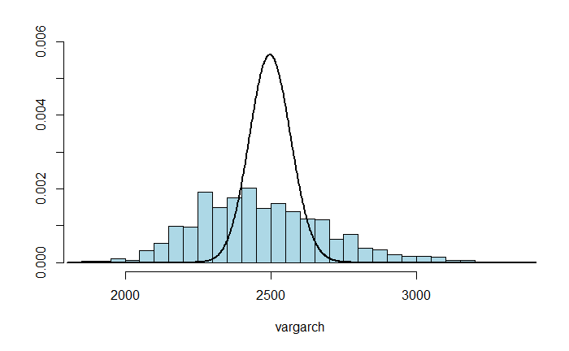